# Projet 2024 M2 ISF

Raphaël VINTELER  
Ghada AYED  
Nicolas DARBOUX

**Abstrait**

**Objectif de l’étude**

Pour rappel, le jeu de données est composé d’une série de mesures biomédicales de *42* personnes (**sujet**) atteintes d’une maladie dégénérative à un stade précoce, recrutées pour un essai de six mois d’un dispositif de télésurveillance permettant de suivre l’évolution des symptômes dans le temps (**duree**).  
L’objectif principal de ce projet de données est de construire un modèle de prédiction du score (**score**) en fonction du temps écoulé depuis le recrutement dans l’essai (**duree**) et de tout ou partie des variables (régresseurs/facteurs) contenues dans l’ensemble de données. La variable duree est donc incluse dans l’étude.

**Dataset fourni**

le train contient *4388* observations à partir duquel vous construirez votre modèle final. Notez que le score final doit être calculé à l’échelle (et non sur une transformation de la cible/variable à expliquer).

# **1. Visualisation dataset**

**Head dataframe :**

| sujet | age | genre | duree | score | FF | FF.Abs | FF.RAP | FF.PPQ5 | FF.DDP | AV | AV.dB | AV.APQ3 | AV.APQ5 | AV.APQ11 | AV.DDA | BTC1 | BTC2 | CDNL | EFS | VFNL |
| --- | --- | --- | --- | --- | --- | --- | --- | --- | --- | --- | --- | --- | --- | --- | --- | --- | --- | --- | --- | --- |
| 1 | 72 | 0 | 5.6431 | 28.199 | 0.00662 | 3.380e-05 | 0.00401 | 0.00317 | 0.01204 | 0.02565 | 0.230 | 0.01438 | 0.01309 | 0.01662 | 0.04314 | 0.014290 | 21.640 | 0.41888 | 0.54842 | 0.16006 |
| 1 | 72 | 0 | 12.6660 | 28.447 | 0.00300 | 1.680e-05 | 0.00132 | 0.00150 | 0.00395 | 0.02024 | 0.179 | 0.00994 | 0.01072 | 0.01689 | 0.02982 | 0.011112 | 27.183 | 0.43493 | 0.56477 | 0.10810 |
| 1 | 72 | 0 | 19.6810 | 28.695 | 0.00481 | 2.462e-05 | 0.00205 | 0.00208 | 0.00616 | 0.01675 | 0.181 | 0.00734 | 0.00844 | 0.01458 | 0.02202 | 0.020220 | 23.047 | 0.46222 | 0.54405 | 0.21014 |
| 1 | 72 | 0 | 25.6470 | 28.905 | 0.00528 | 2.657e-05 | 0.00191 | 0.00264 | 0.00573 | 0.02309 | 0.327 | 0.01106 | 0.01265 | 0.01963 | 0.03317 | 0.027837 | 24.445 | 0.48730 | 0.57794 | 0.33277 |
| 1 | 72 | 0 | 33.6420 | 29.187 | 0.00335 | 2.014e-05 | 0.00093 | 0.00130 | 0.00278 | 0.01703 | 0.176 | 0.00679 | 0.00929 | 0.01819 | 0.02036 | 0.011625 | 26.126 | 0.47188 | 0.56122 | 0.19361 |
| 1 | 72 | 0 | 40.6520 | 29.435 | 0.00353 | 2.290e-05 | 0.00119 | 0.00159 | 0.00357 | 0.02227 | 0.214 | 0.01006 | 0.01337 | 0.02263 | 0.03019 | 0.009438 | 22.946 | 0.53949 | 0.57243 | 0.19500 |

**Type des colonnes :**

```
##     sujet       age     genre     duree     score        FF    FF.Abs    FF.RAP
## "integer" "integer" "integer" "numeric" "numeric" "numeric" "numeric" "numeric"
##   FF.PPQ5    FF.DDP        AV     AV.dB   AV.APQ3   AV.APQ5  AV.APQ11    AV.DDA
## "numeric" "numeric" "numeric" "numeric" "numeric" "numeric" "numeric" "numeric"
##      BTC1      BTC2      CDNL       EFS      VFNL
## "numeric" "numeric" "numeric" "numeric" "numeric"
```

**Stats var numériques :**

```
##      score            duree              age           genre
##  Min.   : 5.437   Min.   : -4.263   Min.   :36.0   Min.   :0.0000
##  1st Qu.:14.225   1st Qu.: 35.364   1st Qu.:58.0   1st Qu.:0.0000
##  Median :20.678   Median : 67.759   Median :65.0   Median :0.0000
##  Mean   :21.006   Mean   : 69.313   Mean   :64.6   Mean   :0.3184
##  3rd Qu.:27.490   3rd Qu.:105.270   3rd Qu.:72.0   3rd Qu.:1.0000
##  Max.   :37.957   Max.   :137.870   Max.   :85.0   Max.   :1.0000
##      FF.Abs              FF.DDP               AV              AV.dB
##  Min.   :2.250e-06   Min.   :0.000980   Min.   :0.00306   Min.   :0.0260
##  1st Qu.:2.295e-05   1st Qu.:0.004760   1st Qu.:0.01927   1st Qu.:0.1770
##  Median :3.435e-05   Median :0.006770   Median :0.02754   Median :0.2540
##  Mean   :4.432e-05   Mean   :0.009095   Mean   :0.03441   Mean   :0.3139
##  3rd Qu.:5.346e-05   3rd Qu.:0.009960   3rd Qu.:0.03977   3rd Qu.:0.3630
##  Max.   :4.456e-04   Max.   :0.172630   Max.   :0.26863   Max.   :2.1070
```

On observe plusieurs choses d’après le summmary :

- On a bien 42 sujets
- On observe un minimum de durée négatif que l’on analysera par la suite
- Des scores strictement postifs compris entre 5 et 38

La plupart des variables sont des variables numériques. Nous transformons les variables catégoriques **genre** et **sujet** en facteurs via la commande :

```r
train$sujet <- as.factor(train$sujet)
train$genre <- as.factor(train$genre)
levels(train$genre) <- c('M', 'F')

testX$sujet <- as.factor(testX$sujet)
testX$genre <- as.factor(testX$genre)
levels(testX$genre) <- c('M', 'F')
```

Nous vérifions également que nous n’avons pas de valeurs NA dans notre dataset :

```r
listMissingColumns <- colnames(train)[apply(train, 2, anyNA)]
print(listMissingColumns)
```

```
## character(0)
```

Enfin nous vérifions s’il n’y a pas de lignes dupliquées :

```r
cat('Nb de lignes dupliquées : ', sum(duplicated(train)))
```

```
## Nb de lignes dupliquées :  0
```

# **2. Analyse descriptive**

## **2.1 Etude de la variable score**

Observons dans un premier temps la distribution de la variable réponse **score** :

**Valeur de quantiles :**

```
##    Min. 1st Qu.  Median    Mean 3rd Qu.    Max.
##   5.437  14.225  20.678  21.006  27.490  37.957
```

**Histogramme et boxplot :**

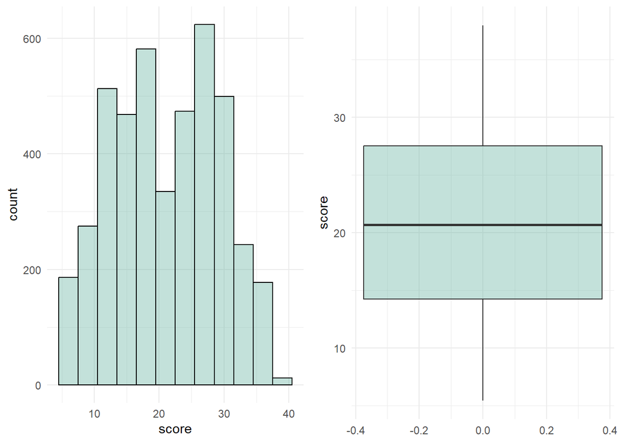

On observe que la distribution est relativement symétrique et strictement positive. Nous testons dans un premier temps les modèles linéaires gaussiens dans l’objectif d’étudier les résidus afin de valider ou non les hypothèses de Gauss-Markov. Nous testerons par la suite des GLM à lois continues positives (Gamma, log-normale, normale tronquée, …).

## **2.2 Etude variable duree**

Vérifions également la distribution de **durée** :

```
##    Min. 1st Qu.  Median    Mean 3rd Qu.    Max.
##  -4.263  35.364  67.759  69.313 105.270 137.870
```

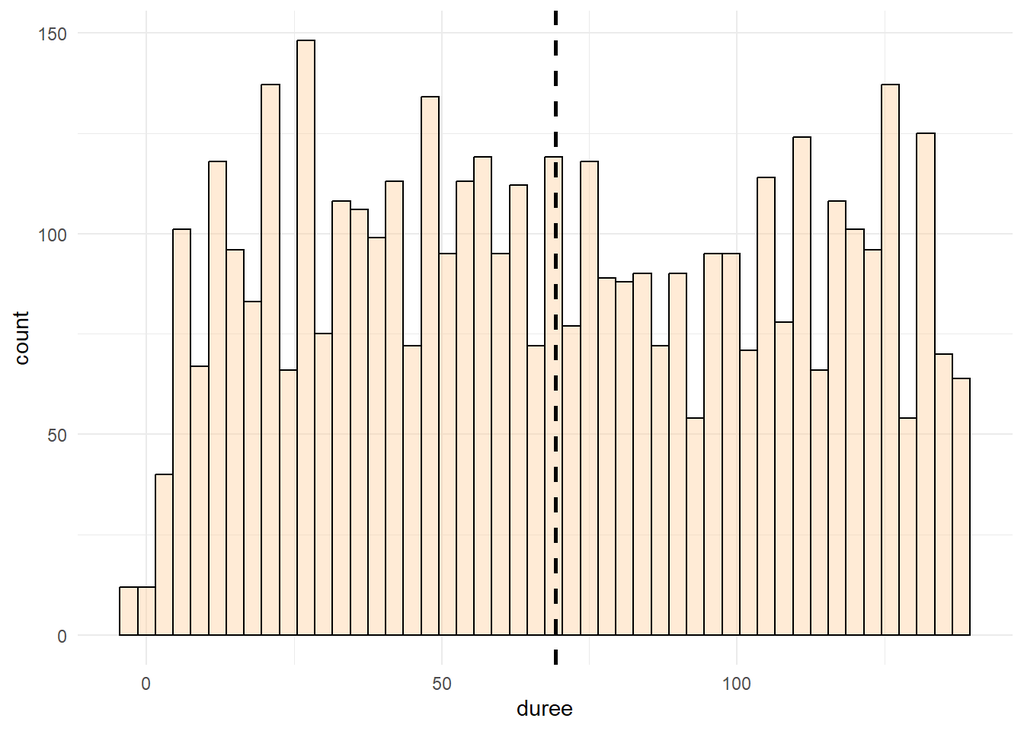

Nous observons des durées négatives, affichons les sujets concernés par ces durées :

```
##  [1] 34 34 34 34 34 34 42 42 42 42 42 42
```

| sujet | age | genre | duree | score |
| --- | --- | --- | --- | --- |
| 34 | 59 | M | -3.31250 | 29.291 |
| 34 | 59 | M | 3.27500 | 28.712 |
| 34 | 59 | M | 10.58100 | 28.070 |
| 34 | 59 | M | 17.57700 | 27.455 |
| 42 | 61 | M | -4.26250 | 19.725 |
| 42 | 61 | M | 0.39583 | 20.026 |
| 42 | 61 | M | 9.71040 | 20.626 |
| 42 | 61 | M | 16.70800 | 21.078 |

Nous observons qu’il s’agit uniquement des sujets *34* et *42* et de leur premières valeurs. Nous partons du principe que ces valeurs négatives correspondent à des analyses antérieurs au début du test et décidons de les conserver (par exemple de patients qui ont changé de médecins et ont apporté leurs anciens bilans pour l’étude). Etant de plus des cas marginales, nous décidons de les conserver.

**Comparaison jeu de test**

Nous comparons les valeurs de durées pour chaque sujets entre le *train set* et le *test set* fourni :

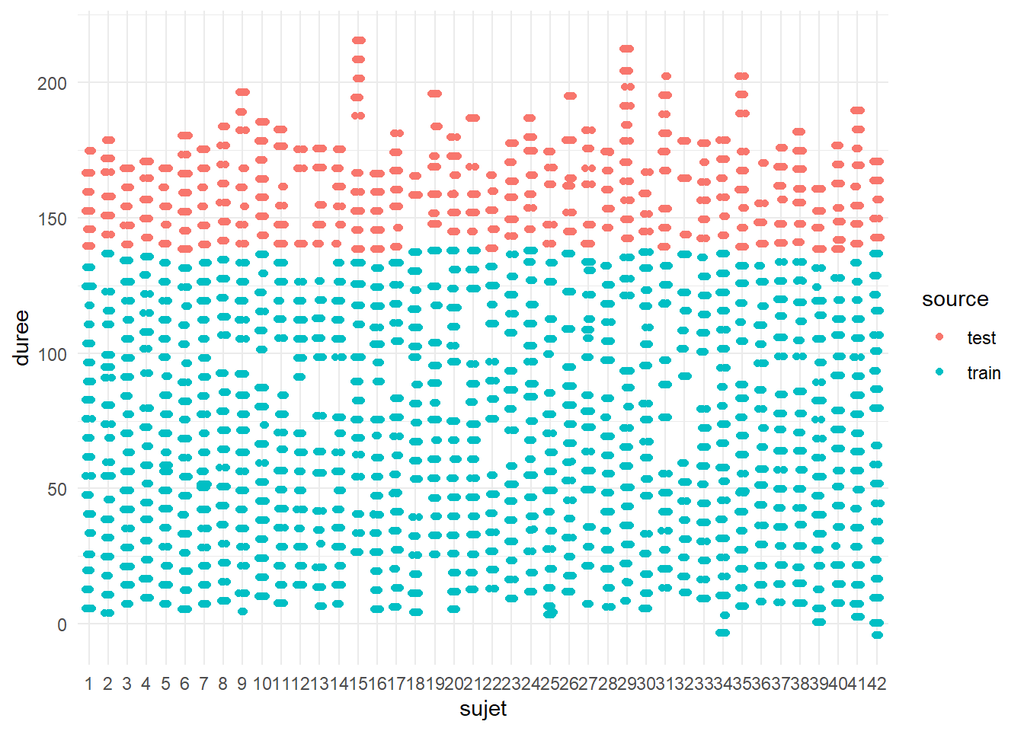

Via un graphique stripchart, nous voyons que pour tous les sujets, les durées du jeu de test sont dans la continuité de celles présentes dans le train.

Enfin vérifions si tous les sujets du jeu de test se retrouvent sur le train :

```r
all(testX$sujet %in% train$sujet)
```

```
## [1] TRUE
```

**Valeurs de durée dupliquées**

En explorant le dataset, nous observons qu’un même sujet apparait plusieurs fois avec la même durée. Par exemple le sujet 1 possède plusieurs durées à environ 5.645 (arrondi) :

| sujet | age | genre | duree | score | FF | FF.Abs | FF.RAP | FF.PPQ5 | FF.DDP | AV | AV.dB | AV.APQ3 | AV.APQ5 | AV.APQ11 | AV.DDA | BTC1 | BTC2 | CDNL | EFS | VFNL | entier |
| --- | --- | --- | --- | --- | --- | --- | --- | --- | --- | --- | --- | --- | --- | --- | --- | --- | --- | --- | --- | --- | --- |
| 1 | 72 | M | 5.6431 | 28.199 | 0.00662 | 3.380e-05 | 0.00401 | 0.00317 | 0.01204 | 0.02565 | 0.230 | 0.01438 | 0.01309 | 0.01662 | 0.04314 | 0.014290 | 21.640 | 0.41888 | 0.54842 | 0.160060 | 5 |
| 1 | 72 | M | 5.6431 | 28.199 | 0.00348 | 1.547e-05 | 0.00124 | 0.00133 | 0.00372 | 0.01192 | 0.113 | 0.00411 | 0.00463 | 0.00949 | 0.01234 | 0.009238 | 27.927 | 0.37340 | 0.52499 | 0.170660 | 5 |
| 1 | 72 | M | 5.6438 | 28.199 | 0.00413 | 2.067e-05 | 0.00173 | 0.00165 | 0.00520 | 0.01282 | 0.125 | 0.00555 | 0.00651 | 0.01103 | 0.01665 | 0.030790 | 26.641 | 0.50911 | 0.53637 | 0.251830 | 5 |
| 1 | 72 | M | 5.6451 | 28.199 | 0.00217 | 1.144e-05 | 0.00086 | 0.00099 | 0.00259 | 0.00798 | 0.072 | 0.00271 | 0.00354 | 0.00781 | 0.00812 | 0.004547 | 30.749 | 0.41216 | 0.54572 | 0.094704 | 5 |
| 1 | 72 | M | 5.6458 | 28.199 | 0.00294 | 1.456e-05 | 0.00121 | 0.00125 | 0.00362 | 0.01058 | 0.098 | 0.00459 | 0.00495 | 0.00888 | 0.01377 | 0.014919 | 27.530 | 0.40986 | 0.53572 | 0.166350 | 5 |
| 1 | 72 | M | 5.6458 | 28.199 | 0.00250 | 1.278e-05 | 0.00110 | 0.00090 | 0.00331 | 0.00631 | 0.058 | 0.00222 | 0.00259 | 0.00579 | 0.00665 | 0.003822 | 32.102 | 0.31053 | 0.52767 | 0.065937 | 5 |

Nous observons également que la variance des variables pour cette même durée est relativement élevée. Il est difficile sans avis du métier de savoir si ces observations constituent des anomalies (et encore plus quelles lignes garder si c’est le cas !). Nous supposons qu’il s’agisse d’un seul prélevement et que les résultats sont observés à par exemple plusieurs heures à la même journée.  
Nous partons du principe alors que ces lignes ne sont pas des erreurs du dataset malgré le caractère étrange de celles-ci et les conservons donc.

## **2.3 Etude de l’age**

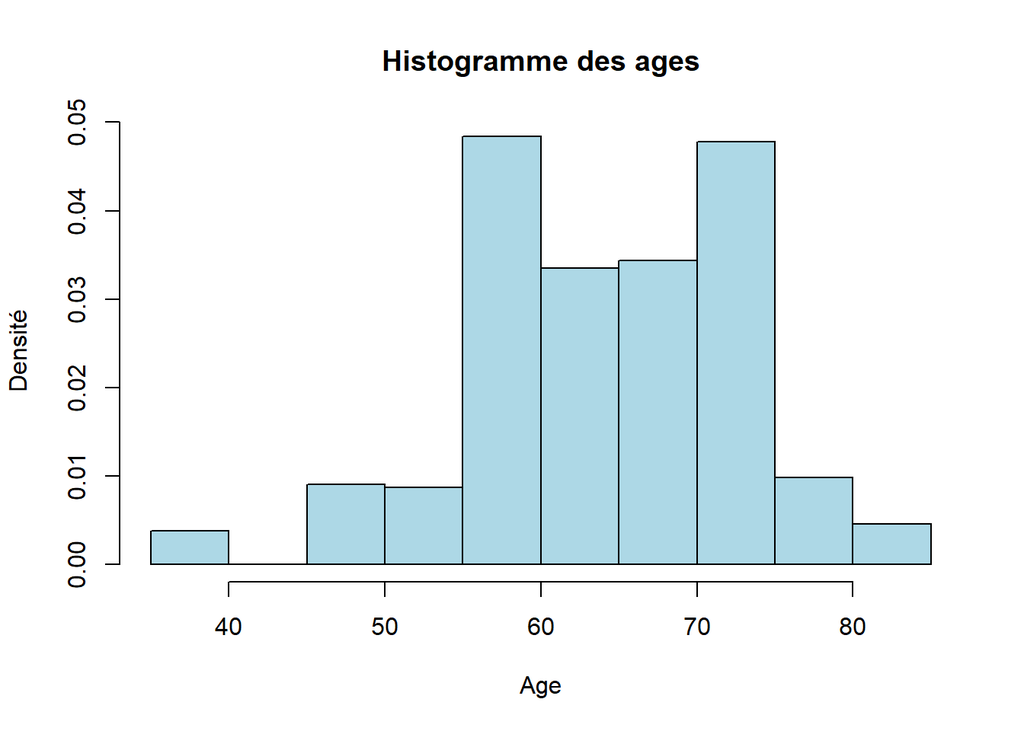

La variable **age** est comprise entre 36 et 85, avec certaines disproportions par tranches.  
Nous décidons de segmenter la variable **age** via les tranches suivantes :

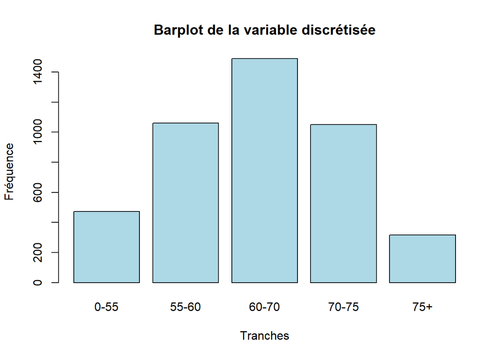

## **2.4 Etude bivariée**

#### **Variables Numériques**

Dans cette partie nous souhaitons étudier la relation entre le **score** et les features. Comme notre jeu de données ne contient pas énormément de variables nous pouvons explorer graphiquement ces dernières. Pour les variables numériques, nous crééons un graphique de Pareto qui se lit de cette manière :

- L’histogramme en gris represente la distribution de la variable numérique avec comme échelle *Count* à gauche.
- La ligne rouge represente la moyenne de score des individus présents dans chaque bins des histogrammes, avec l’échelle *Average score* à droite.

Notre objectif est d’observer d’un premier coup d’oeil des relations potentiellement importantes avec notre variable target.

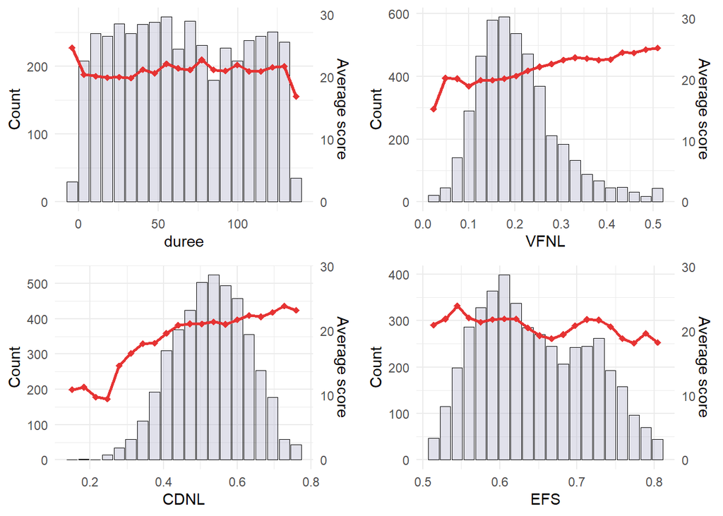

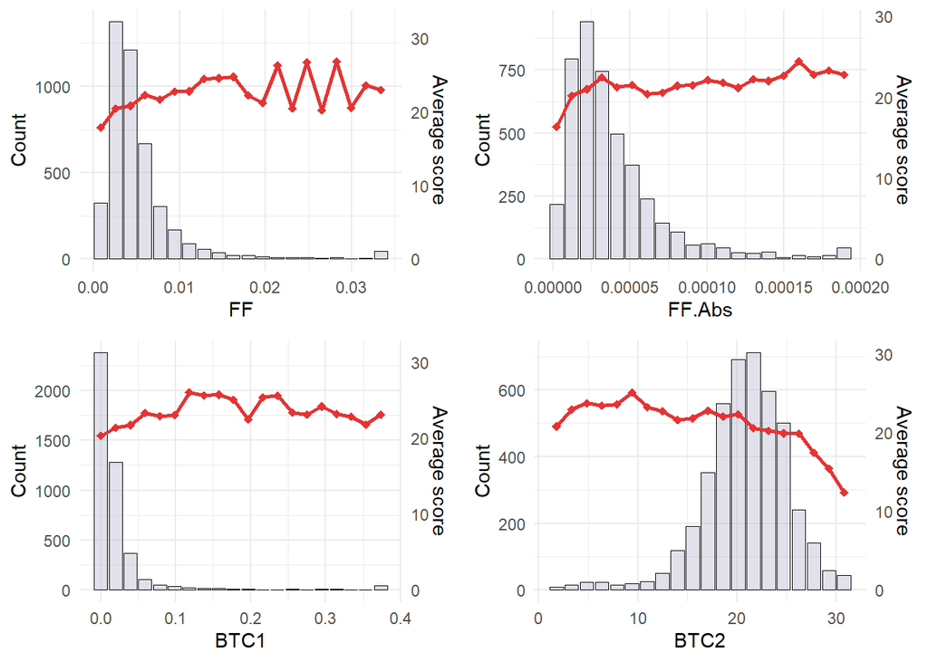

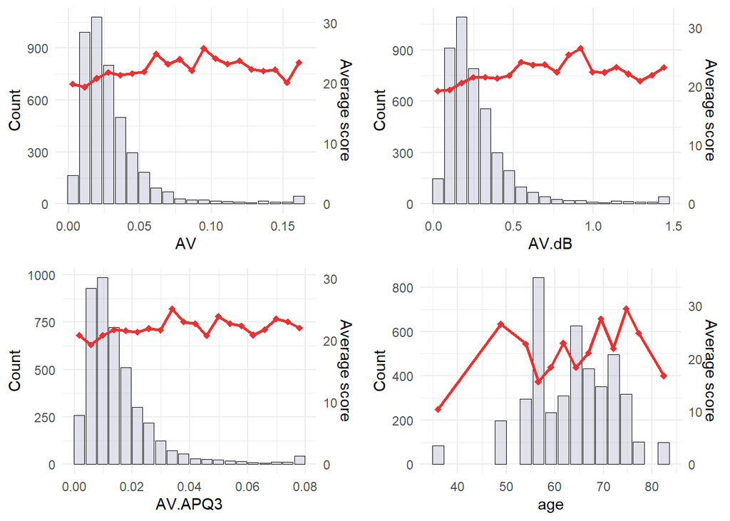

Pour les variables affichées, il est difficile d’observer une tendance forte avec le **score**, seulement quelques relations légèrement monotones pour certaines d’entre elles.

#### **Variables catégoriques :**

**Genre**

Le dataset comporte globalement plus d’hommes que de femmes, nous pouvons le vérifier :

```
##   Genre Frequence
## 1     M      2991
## 2     F      1397
```

[figure not shown]

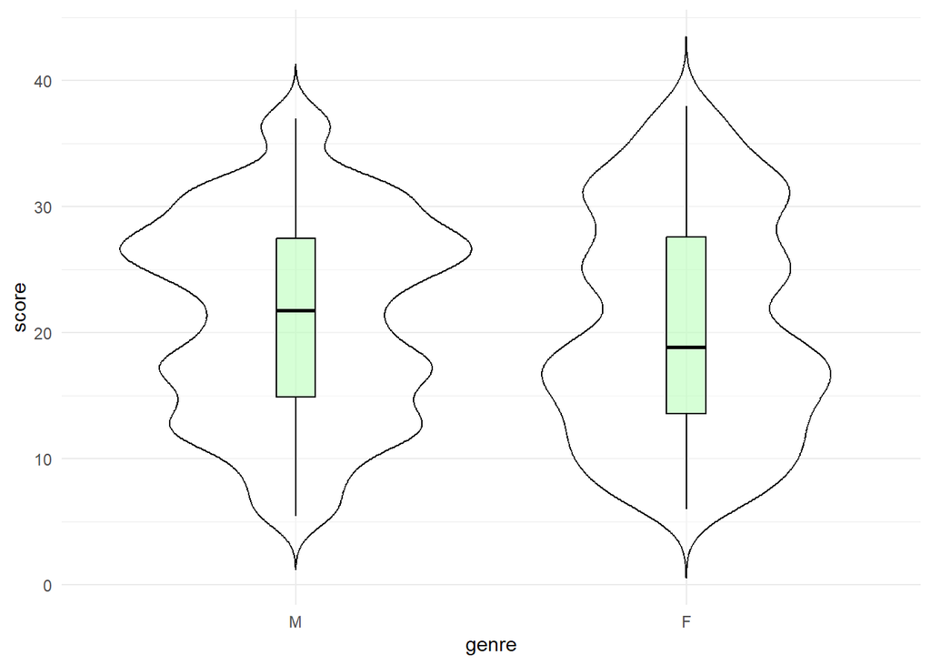

On observe que le premier et deuxième quantiles de score sont relativement différents entre les hommes et les femmes. Egalement les distributions de score pour les 2 genres n’ont pas d’outliers et ne sont pas asymétriques.

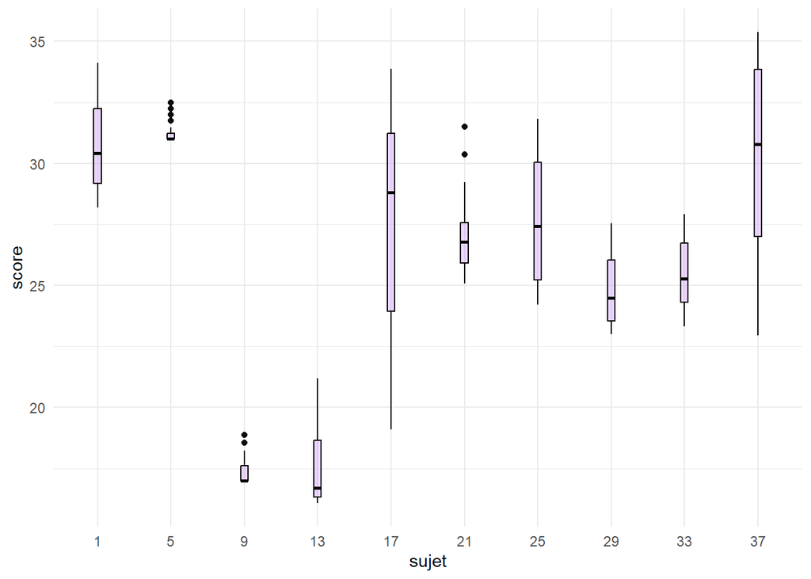

Concernant les sujets, on observe que leurs scores sont très différents entre eux. Notons également pour certains sujets la présence d’outliers parmi leurs scores ( > 1.5 l’IQR).

## **2.5 Corrélations des variables**

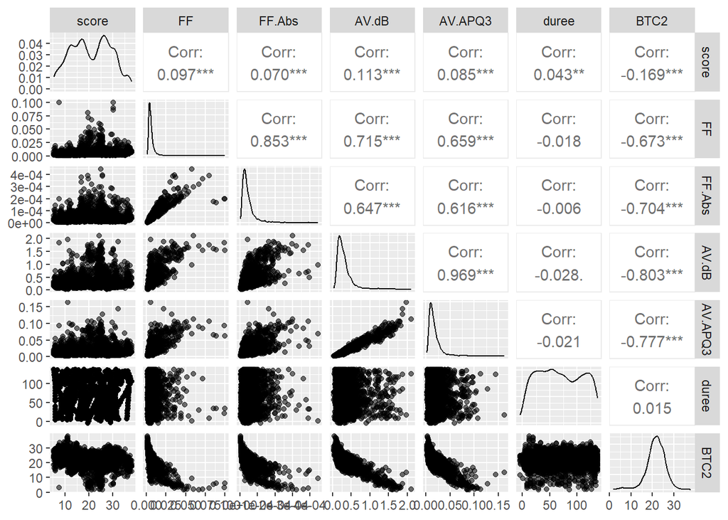

Nous observons ici des corrélations élevées entre certaines variables dépendantes, en particulier celles relatives à la fréquence vocale (FF) et à l’amplitude (AA) Cela suggère l’existence d’informations redondantes au sein des variables qui peuvent affecter les coefficients finaux. Nous pouvons l’observer plus clairement avec un graphique de corrélation ordonné :

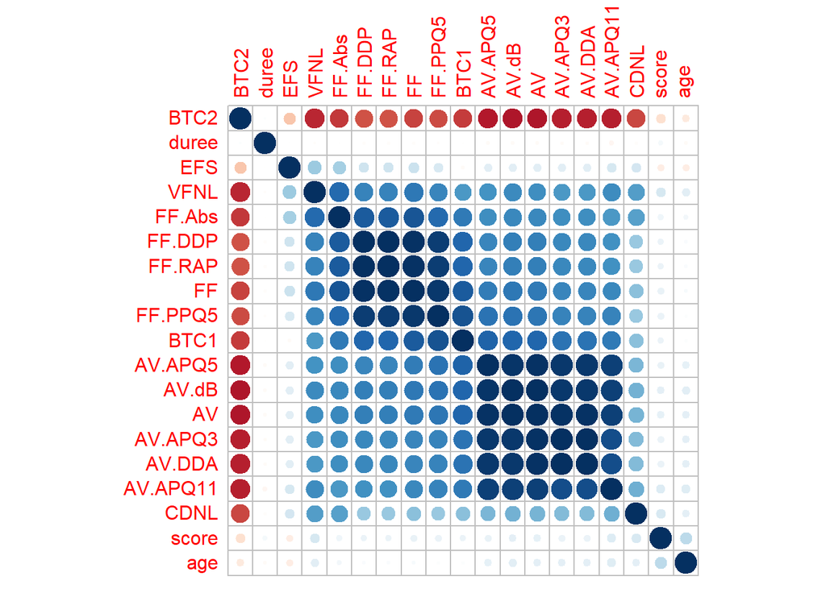

Nous observons 2 blocs de variables fortement corrélées entre elles (FF et AA en bleu foncée). Notons aussi les faibles corrélations entre le **score** et les variables indépendantes.  
Regardons les valeurs exactes de ces corrélations :

```
##               score        duree          FF       FF.Abs      FF.RAP
## score    1.00000000  0.043259503  0.09728728  0.069739318  0.08196194
## duree    0.04325950  1.000000000 -0.01761963 -0.005680196 -0.01962437
## FF       0.09728728 -0.017619628  1.00000000  0.853081886  0.98540887
## FF.Abs   0.06973932 -0.005680196  0.85308189  1.000000000  0.83409008
## FF.RAP   0.08196194 -0.019624366  0.98540887  0.834090075  1.00000000
## FF.PPQ5  0.08536888 -0.011969800  0.96912718  0.778038608  0.94946533
## FF.DDP   0.08198367 -0.019625942  0.98541099  0.834092943  0.99999966
## AV       0.10647160 -0.027993195  0.70999223  0.643036148  0.68091473
## AV.dB    0.11304099 -0.027933494  0.71488909  0.647414852  0.68261631
## AV.APQ3  0.08510384 -0.021184613  0.65909192  0.616172315  0.64327651
## AV.APQ5  0.09697639 -0.029412403  0.69407826  0.614730253  0.65866862
## AV.APQ11 0.14383000 -0.047668184  0.64782643  0.578316504  0.60547860
## AV.DDA   0.08510476 -0.021179724  0.65909035  0.616169506  0.64327452
##              FF.PPQ5      FF.DDP         AV       AV.dB     AV.APQ3     AV.APQ5
## score     0.08536888  0.08198367  0.1064716  0.11304099  0.08510384  0.09697639
## duree    -0.01196980 -0.01962594 -0.0279932 -0.02793349 -0.02118461 -0.02941240
## FF        0.96912718  0.98541099  0.7099922  0.71488909  0.65909192  0.69407826
## FF.Abs    0.77803861  0.83409294  0.6430361  0.64741485  0.61617232  0.61473025
## FF.RAP    0.94946533  0.99999966  0.6809147  0.68261631  0.64327651  0.65866862
## FF.PPQ5   1.00000000  0.94946955  0.7297561  0.73122402  0.66995822  0.73120571
## FF.DDP    0.94946955  1.00000000  0.6809133  0.68261610  0.64327438  0.65866480
## AV        0.72975606  0.68091327  1.0000000  0.99338411  0.98022694  0.98476617
## AV.dB     0.73122402  0.68261610  0.9933841  1.00000000  0.96935961  0.97773897
## AV.APQ3   0.66995822  0.64327438  0.9802269  0.96935961  1.00000000  0.96160636
## AV.APQ5   0.73120571  0.65866480  0.9847662  0.97773897  0.96160636  1.00000000
## AV.APQ11  0.66726351  0.60547926  0.9338580  0.93498486  0.88257549  0.93808712
## AV.DDA    0.66995693  0.64327239  0.9802266  0.96935947  0.99999998  0.96160688
##             AV.APQ11      AV.DDA
## score     0.14383000  0.08510476
## duree    -0.04766818 -0.02117972
## FF        0.64782643  0.65909035
## FF.Abs    0.57831650  0.61616951
## FF.RAP    0.60547860  0.64327452
## FF.PPQ5   0.66726351  0.66995693
## FF.DDP    0.60547926  0.64327239
## AV        0.93385798  0.98022657
## AV.dB     0.93498486  0.96935947
## AV.APQ3   0.88257549  0.99999998
## AV.APQ5   0.93808712  0.96160688
## AV.APQ11  1.00000000  0.88257525
## AV.DDA    0.88257525  1.00000000
```

En regardant ces valeurs, il est clair que toutes les variables blocs FF et AA sont corrélées (presque 70% pour la majorité). Egalement nous avons des corrélations de quasiment 1 (0.99) au sein des blocs FF et AA. Enfin la variable **BTC2** ne forme pas un bloc mais est très corrélée négativement avec la majorité des varibales.

Par la suite dans une de nos méthodes de sélections de variables. Nous ne choisirons qu’une variable, celle la plus corrélée avec le score, pour chaque bloc (FF et AA). Ici nous remarquons qu’il s’agit pour le bloc FF de la variable **FF** et pour le bloc AA la variable **AV.APQ11**.

Nous calculons également pour les variables catégorielles, à savoir **sujet**, **age** (discretisé) et **genre** le coefficient V de Cramer. Le V de Cramer est une mesure d’association, basée sur la statistique du χ2 de Pearson, avec des valeurs comprises entre 0 et 1. Nous obtenons la matrice de corrélation suivante :

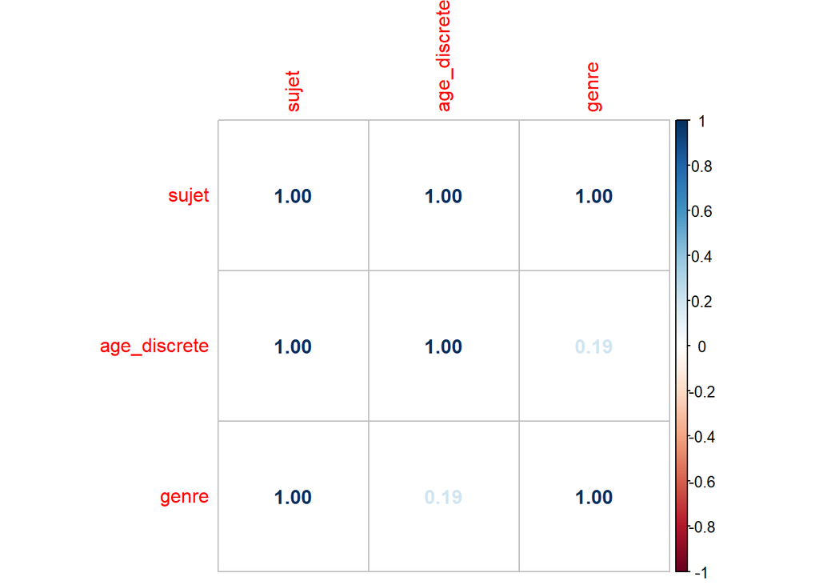

On observe alors des valeurs d’association maximale pour la variable **sujet** par rapport aux autres variables catégorielles. Ce qui parait cohérent puisque l’information de l’age et du genre sont déjà capté par la variable **sujet**.

## **2.6 Focus sur score vs duree**

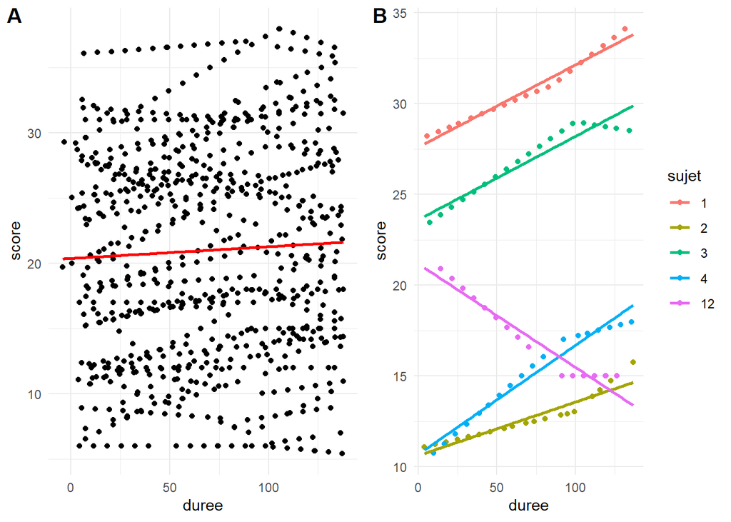

Aucune relation n’apparaît à première vue lorsque l’on regarde le score par rapport à la durée seule sur **A**.  
Cependant, lorsque nous représentons la durée pour certains sujets spécifiques sur **B**, elle semble suivre une tendance qui dépend de la durée, qu’elle soit croissante, décroissante ou constante.

Cela est principalement dû au fait que notre jeu de données est un *“panel dataset”*, avec les mêmes individus (**sujet**) plusieurs fois en tant qu’observation, mais à des instants différents (**duree**). Cela peut être problématique dans la partie modélisation car cela entraîne souvent une autocorrélation (résidus dépendants les uns des autres), on vérifiera cette hypothèse lors de la construction de nos modèles. Si cela est avérée,les modèles linéaires ne serons pas adaptés à ce type de problème, et nous devrons nous tourner vers d’autres solutions.

Enfin, notons que la tendance linéaire par sujet semble changer à partir d’une certaine durée (environ 70%).

## **2.7 Création des nouvelles variables avec ACP:**

Comme nous l’avons observé, nos variables cliniques sont très corrélées entre elles, nous crééons donc de nouvelles variables comme combinaisons linéaires de ces dernières.

```
## Importance of first k=5 (out of 16) components:
##                          PC1     PC2     PC3     PC4     PC5
## Standard deviation     4.350 0.14767 0.07657 0.07184 0.05342
## Proportion of Variance 0.998 0.00115 0.00031 0.00027 0.00015
## Cumulative Proportion  0.998 0.99920 0.99951 0.99978 0.99993
```

En regardant les composantes principales et leurs proportions de variances, on ne garde que la première car celle-ci conserve déjà plus de 99 % de la variance expliquée.

## **2.8 Split des données**

Nous divisons le train set original en base d’apprentissage, de validation et de test avec une proportion respective de *70/10/20* %, pour évaluer la performance du modèle sur une partie de notre jeu de données.  
Le set de validation nous permet de selectionner et tuner les modèles entre eux en limitant le risque d’overfit. Le set de test quant à lui nous permettra d’estimer sans biais l’erreur attendu sur le set sans labels, et de conclure sur l’efficacité de notre modèle retenu.  
Egalement Comme il s’agit d’un panel dataset, il est important de ne pas séparer simplement de manière aléatoire le jeu de validation et le jeu d’entrainement.  
Nous voulons tenir compte des ordres chronologiques des analyses. Pour cela nous calculons le quantile 70% et 80% pour chaque sujet puis repartissons les sets de cette manière :

- inférieur à 70% quantile, *set d’apprentissage*
- compris entre 70% et 80%, *set de validation*
- supérieur à 80%, *set de test*

```r
quantiles_1 <- train_selected %>%
  group_by(sujet) %>%
  summarize(value_quantile_1 = quantile(duree, 0.7))

quantiles_2 <- train_selected %>%
  group_by(sujet) %>%
  summarize(value_quantile_2 = quantile(duree, 0.8))

train_result <- train_selected %>%
  left_join(quantiles_1, by = "sujet")
train_result <- train_result %>%
  left_join(quantiles_2, by = "sujet")

apprentissage <- train_result %>%
  filter(duree <=value_quantile_1)
validation <- train_result %>%
  filter(duree > value_quantile_1 & duree <= value_quantile_2)
test <- train_result %>%
  filter(duree >value_quantile_2)

drop <- c("value_quantile_1","value_quantile_2")
apprentissage = apprentissage[,!(names(apprentissage) %in% drop)]
validation = validation[,!(names(validation) %in% drop)]
test = test[,!(names(test) %in% drop)]
```

# **3. Modélisation**

## **3.1 Modèles LM**

Dans cette partie, nous allons dans un premier temps construire 3 modèles linéaires “naïfs” :

- Le premier avec seulement *duree* et *sujet*
- Le deuxième avec toutes les variables sauf *sujet*
- Le troisième avec toutes les variables

#### **Modèle réduit à l’intercept**

Nous construisons le modèle réduit à l’intercept qui servira de comparaison pour les modèles suivant.

```
##
## Call:
## lm(formula = score ~ 1, data = apprentissage)
##
## Residuals:
##      Min       1Q   Median       3Q      Max
## -14.7297  -7.2426  -0.3126   6.5304  16.3214
##
## Coefficients:
##             Estimate Std. Error t value Pr(>|t|)
## (Intercept)  20.6666     0.1444   143.1   <2e-16 ***
## ---
## Signif. codes:  0 '***' 0.001 '**' 0.01 '*' 0.05 '.' 0.1 ' ' 1
##
## Residual standard error: 8.047 on 3103 degrees of freedom
```

#### **Modèle : score ~ duree + sujet**

Nous testons un premier modèle linéaire avec comme seules variables explicatives **duree** et **sujet**. Notons que ce summary n’affiche pas l’integralité des coefficients (via une fonction de display custom) des sujets dans un soucis de lisibilité :

```r
model_lm_1 <- lm(formula= score~ sujet + duree ,data=apprentissage)
my.summary.lm(summary(model_lm_1),my.rows = c(2:4, 10, 20, 30, 41:43))
```

```
##
## Call:
## lm(formula = score ~ sujet + duree, data = apprentissage)
##
## Residuals:
##     Min      1Q  Median      3Q     Max
## -6.7473 -0.5473  0.0025  0.5658  6.0380
##
## Coefficients:
##           Estimate Std. Error t value Pr(>|t|)
## sujet2  -17.771440   0.239051 -74.342  < 2e-16 ***
## sujet3   -3.733841   0.236789 -15.769  < 2e-16 ***
## sujet4  -15.822990   0.239872 -65.964  < 2e-16 ***
## sujet10 -17.796522   0.240675 -73.944  < 2e-16 ***
## sujet20 -18.486207   0.244070 -75.741  < 2e-16 ***
## sujet30  -1.152170   0.241499  -4.771 1.92e-06 ***
## sujet41   3.212556   0.234681  13.689  < 2e-16 ***
## sujet42  -6.898739   0.234761 -29.386  < 2e-16 ***
## duree     0.018823   0.001011  18.610  < 2e-16 ***
## ---
## Signif. codes:  0 '***' 0.001 '**' 0.01 '*' 0.05 '.' 0.1 ' ' 1
##
## Residual standard error: 1.507 on 3061 degrees of freedom
## Multiple R-squared:  0.9654, Adjusted R-squared:  0.9649
## F-statistic:  2034 on 42 and 3061 DF,  p-value: < 2.2e-16
```

```
## RMSE train :  1.4964
```

```
## RMSE validation :  2.635391
```

On observe un meilleur RSE que le modèle réduit à l’intercept, ainsi qu’un R carré elevé. Le RMSE est également plus élevé dans le set de validation, nous investiguerons cet écart par la suite.

#### **Modèle : score ~ . - sujet**

```r
model_lm_2 <- lm(formula= score ~. - sujet - PC1 ,data=apprentissage) # -PC1 on enlève la composante principale custom créee précédemment
summary(model_lm_2)
```

```
##
## Call:
## lm(formula = score ~ . - sujet - PC1, data = apprentissage)
##
## Residuals:
##      Min       1Q   Median       3Q      Max
## -28.1425  -6.1373  -0.7632   6.1674  18.8836
##
## Coefficients:
##               Estimate Std. Error t value Pr(>|t|)
## (Intercept)  3.715e+01  3.099e+00  11.985  < 2e-16 ***
## duree        7.360e-03  5.074e-03   1.451 0.147014
## FF           5.042e+02  2.171e+02   2.322 0.020305 *
## FF.Abs      -3.368e+04  8.852e+03  -3.804 0.000145 ***
## FF.RAP      -1.276e+04  5.048e+04  -0.253 0.800433
## FF.PPQ5     -2.861e+02  1.798e+02  -1.591 0.111799
## FF.DDP       4.159e+03  1.683e+04   0.247 0.804816
## AV           2.164e+02  7.250e+01   2.986 0.002852 **
## AV.dB       -9.441e+00  5.636e+00  -1.675 0.093995 .
## AV.APQ3      2.559e+04  5.036e+04   0.508 0.611443
## AV.APQ5     -1.160e+02  6.147e+01  -1.887 0.059242 .
## AV.APQ11     7.974e+01  2.585e+01   3.084 0.002059 **
## AV.DDA      -8.614e+03  1.679e+04  -0.513 0.607903
## BTC1        -1.899e+01  6.468e+00  -2.937 0.003343 **
## BTC2        -3.622e-01  7.218e-02  -5.018 5.52e-07 ***
## CDNL         7.174e+00  1.913e+00   3.751 0.000179 ***
## EFS         -2.360e+01  2.361e+00  -9.999  < 2e-16 ***
## VFNL         1.534e+01  3.069e+00   4.998 6.10e-07 ***
## ---
## Signif. codes:  0 '***' 0.001 '**' 0.01 '*' 0.05 '.' 0.1 ' ' 1
##
## Residual standard error: 7.616 on 3086 degrees of freedom
## Multiple R-squared:  0.1092, Adjusted R-squared:  0.1043
## F-statistic: 22.25 on 17 and 3086 DF,  p-value: < 2.2e-16
```

```
## RMSE train :  7.59365
```

```
## RMSE validation :  8.142571
```

Les résultats sont bien moins satisfaisant que le premier modèle précédent avec un RSE proche du model null Le RMSE quant à lui est de plus de 7, ce qui est loin d’être bon au vu de la plage de **score** allant de 5 à 38. Nous montrons ainsi l’importance de la variable **sujet** dans notre jeu de données. Nous testons sur un dernier modèle avec toutes les variables pour valider notre hypothèse.

#### **Modèle : score ~ .**

```r
model_lm_3 <- lm(formula= score ~. - PC1 ,data=apprentissage) # -PC1 on enlève la composante principale custom créee précédemment
my.summary.lm(summary(model_lm_3),my.rows = c(2:4, 41:59))
```

```
##
## Call:
## lm(formula = score ~ . - PC1, data = apprentissage)
##
## Residuals:
##     Min      1Q  Median      3Q     Max
## -6.9821 -0.5794 -0.0081  0.6172  6.1088
##
## Coefficients:
##            Estimate Std. Error t value Pr(>|t|)
## sujet2   -1.711e+01  2.899e-01 -59.014  < 2e-16 ***
## sujet3   -3.749e+00  2.378e-01 -15.763  < 2e-16 ***
## sujet4   -1.533e+01  2.704e-01 -56.701  < 2e-16 ***
## sujet41   3.838e+00  2.605e-01  14.736  < 2e-16 ***
## sujet42  -6.631e+00  2.440e-01 -27.171  < 2e-16 ***
## duree     1.874e-02  1.010e-03  18.550  < 2e-16 ***
## FF       -1.030e+02  4.594e+01  -2.242  0.02501 *
## FF.Abs    8.942e+02  2.198e+03   0.407  0.68411
## FF.RAP   -5.247e+03  9.947e+03  -0.527  0.59790
## FF.PPQ5   1.112e+01  3.956e+01   0.281  0.77868
## FF.DDP    1.809e+03  3.316e+03   0.546  0.58542
## AV        3.263e+01  1.482e+01   2.203  0.02769 *
## AV.dB     4.521e-01  1.156e+00   0.391  0.69566
## AV.APQ3   1.216e+04  9.938e+03   1.224  0.22119
## AV.APQ5  -1.172e+01  1.248e+01  -0.938  0.34811
## AV.APQ11 -1.262e+01  5.333e+00  -2.367  0.01801 *
## AV.DDA   -4.063e+03  3.313e+03  -1.227  0.22007
## BTC1     -7.586e-01  1.471e+00  -0.516  0.60623
## BTC2      5.573e-02  1.857e-02   3.001  0.00272 **
## CDNL     -4.950e-01  4.754e-01  -1.041  0.29781
## EFS      -2.044e+00  8.663e-01  -2.359  0.01837 *
## VFNL     -5.220e-01  7.017e-01  -0.744  0.45700
## ---
## Signif. codes:  0 '***' 0.001 '**' 0.01 '*' 0.05 '.' 0.1 ' ' 1
##
## Residual standard error: 1.493 on 3045 degrees of freedom
## Multiple R-squared:  0.9662, Adjusted R-squared:  0.9656
## F-statistic:  1501 on 58 and 3045 DF,  p-value: < 2.2e-16
```

```
## RMSE train :  1.478843
```

```
## RMSE validation :  2.614845
```

Bien que légérement meilleur, nous obtenons des résultats similaire à notre premier modèle sur le RMSE du test et du train.

#### **Modèle méthode pas à pas**

Ici nous testons de selectionner nos variables via une méthode stepwise.

```r
lm_all <- lm(formula= score ~ . - PC1  ,data=apprentissage)
lm_both <- step(lm_all, direction="both", trace=0)
#my.summary.lm(summary(lm_both),my.rows = c(2:4, 41:length(lm_both$coefficients)))
```

```
## RMSE train :  1.48005
```

```
## RMSE validation :  2.619569
```

#### **Modèle méthodes régularisations**

Nous testons dans cette partie plusieurs méthodes de régularisation à savoir Lasso, Ridge et ElasticNet.

**Lasso**

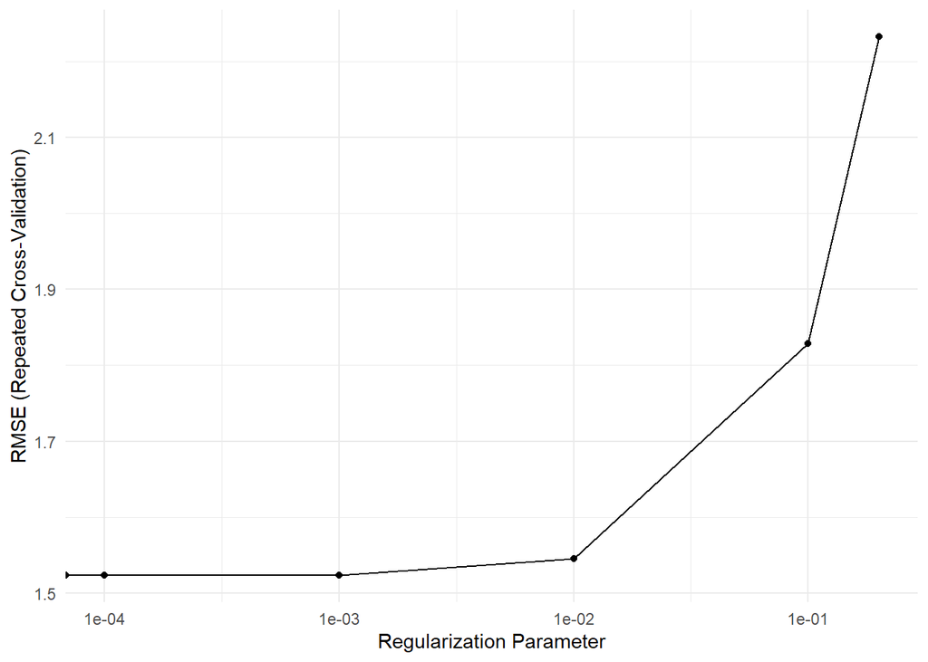

Via la méthode de Lasso, nous voyons que le tuning du paramètre d’erreur ne semble qu’augmenter le RMSE. Nous pouvons le vérifier avec :

```
##   alpha lambda     RMSE  Rsquared      MAE     RMSESD  RsquaredSD      MAESD
## 1     1  0e+00 1.523306 0.9641989 1.015897 0.03785984 0.002145589 0.01269556
## 2     1  1e-04 1.523306 0.9641989 1.015897 0.03785984 0.002145589 0.01269556
## 3     1  1e-03 1.523306 0.9641989 1.015897 0.03785984 0.002145589 0.01269556
## 4     1  1e-02 1.545727 0.9632176 1.047096 0.03512266 0.002119044 0.01444544
## 5     1  1e-01 1.828408 0.9537028 1.309967 0.04574245 0.002749391 0.03188981
## 6     1  2e-01 2.232081 0.9419766 1.737093 0.05943870 0.003619165 0.04118411
```

**Ridge**

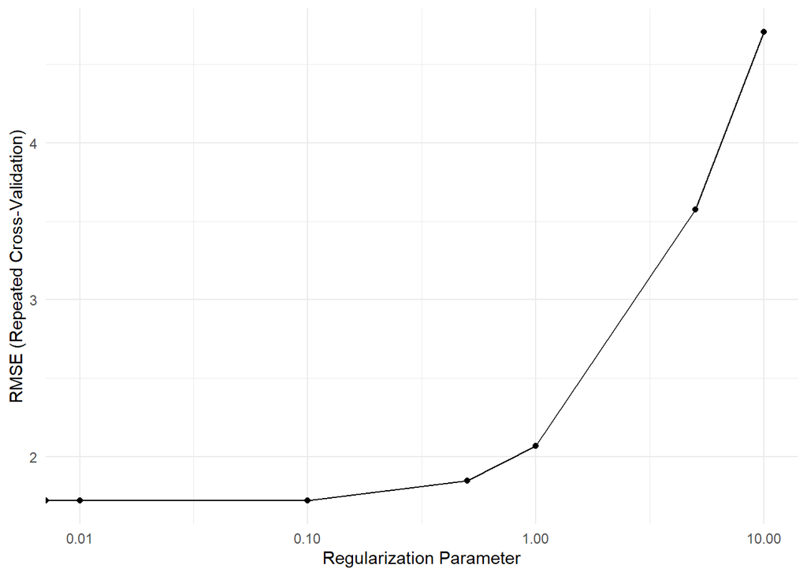

Nous observons le même phénomène pour la régresion Ridge.

**Elastic Net**

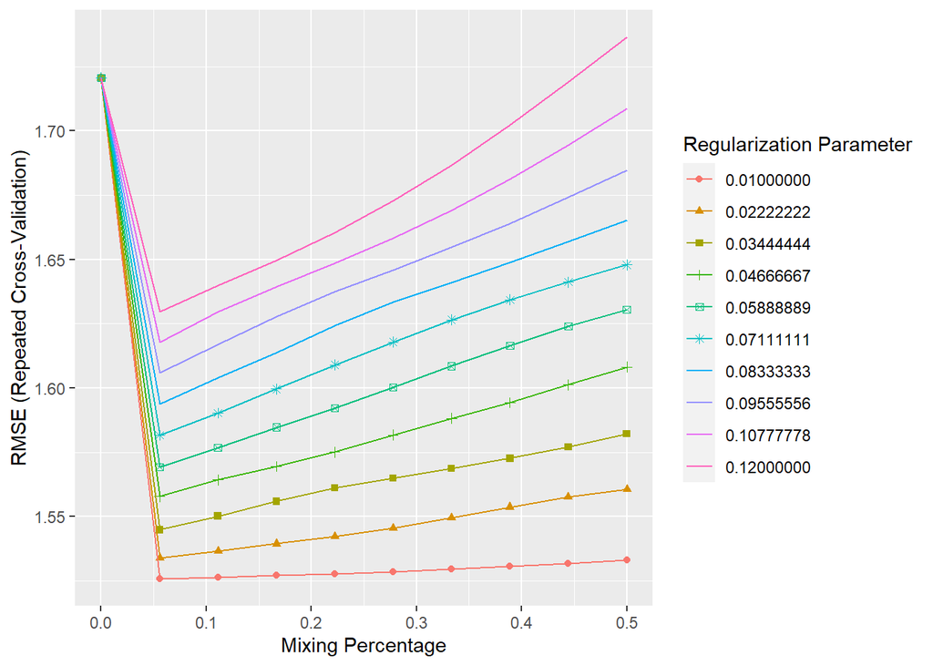

```
## RMSE train :  1.480104
```

```
## RMSE validation :  2.615213
```

### **Résidus : score ~ duree + sujet**

Nous voyons que globalement les résultats sont très similaires entre les modèles, avec un RMSE globalement plus élevé pour la validation. De plus, Le modèle avec seulement 2 variables obtient quasiment les mêmes performances. Analysons les résidus de ce dernier :

*P1*

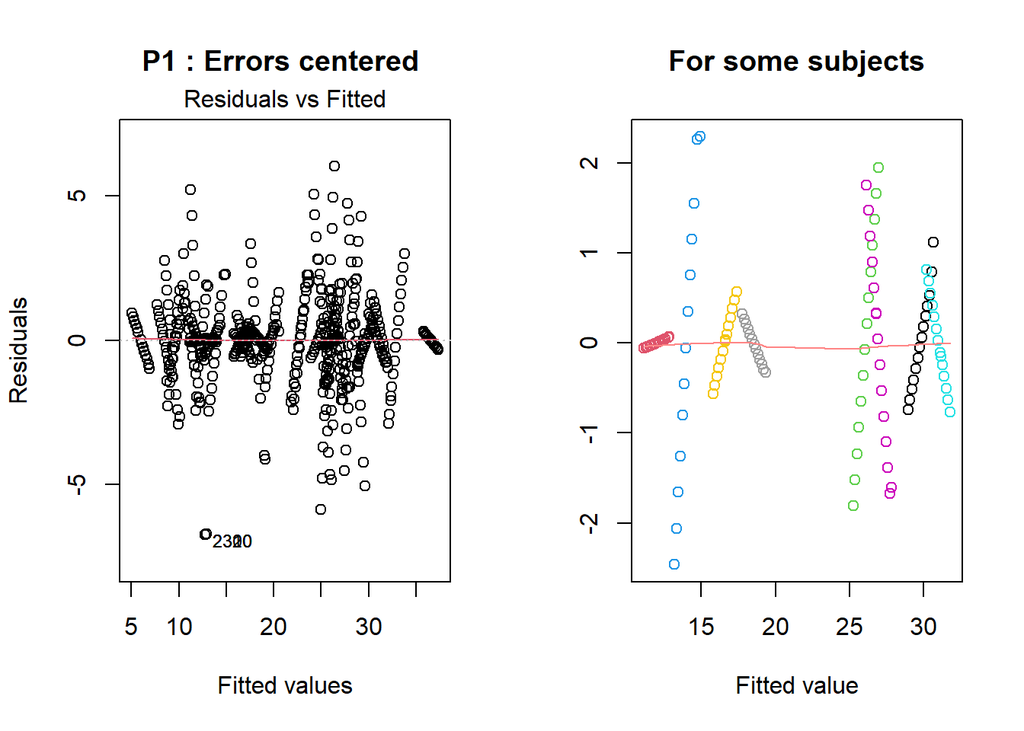

Bien que les résidus soient centrées en 0, nous pouvons observer des patternes dans ces derniers, spécifique aux sujets, comme le montre la 2ème figure.

*P2*

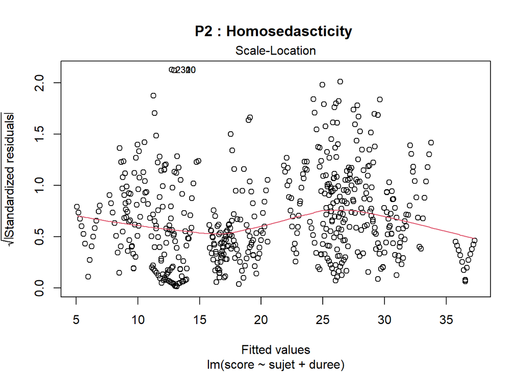

L’hypothèse d’homosedasctisité semble quant à elle être respectée.

*P3*

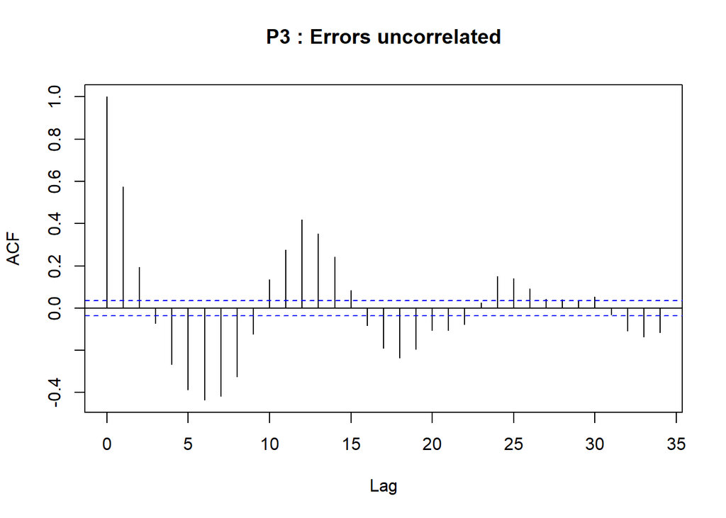

Nous pouvons voir d’après le graphe ACF une clair autocorrélation entre les résidus. Pour s’en convaincre, nous pouvons réaliser un test de Durbin Watson :

```r
durbinWatsonTest(model_lm_1)
```

```
##  lag Autocorrelation D-W Statistic p-value
##    1       0.5731449     0.8528948       0
##  Alternative hypothesis: rho != 0
```

On obtient une p-value proche de 0, nous rejettons l’hypohtèse H0 et concluons que les résidus sont bien corrélées.

*P4*

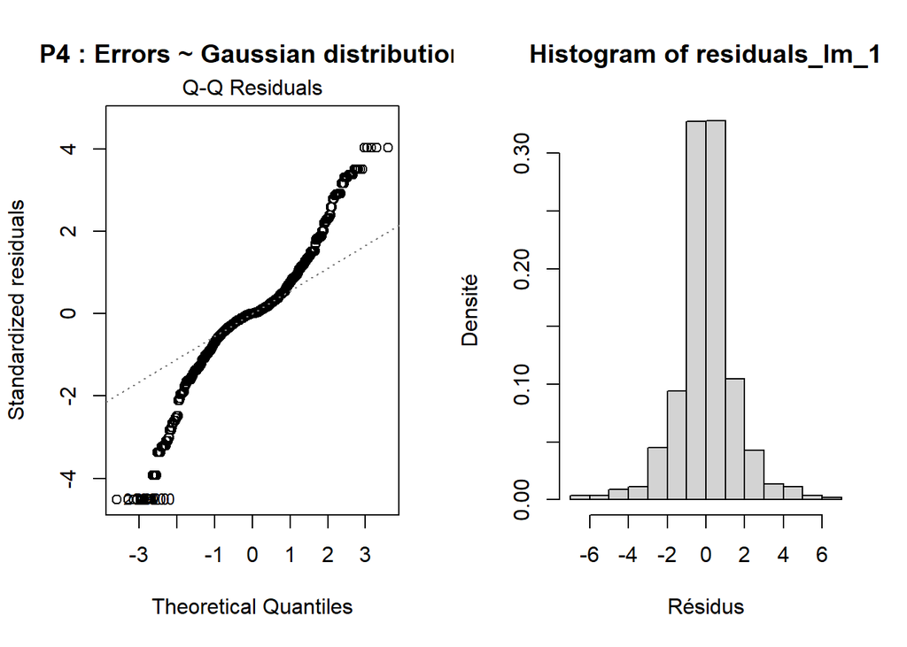

Bien que les résidus semblent symétrique, nous voyons des valeurs éloignés sur le QQplot et l’histogramme. Nous confirmons cela avec un test de Shapiro :

```r
shapiro.test(residuals(model_lm_1))
```

```
##
##  Shapiro-Wilk normality test
##
## data:  residuals(model_lm_1)
## W = 0.92522, p-value < 2.2e-16
```

*Conclusions :*

Comme nous l’avons vu, rajouter le **sujet** permet d’apporter plus de précision au model.  
Cependant nous avons vu via l’analyse de résidus, que les hypothèses du modèle linéaire ne sont pas respectées, surtout pour le cas de l’autocorrélation, de patternes et non normalité dans les résidus. Nous pouvons donc affirmer que des modèles linéaires classiques, ne permettent pas de capter toute l’information propre aux sujets compte tenu des variables que l’on dispose. En effet, ce type de modèle ne permet pas de changer la *pente* de regression pour chaque sujets (voir figure ci dessous).

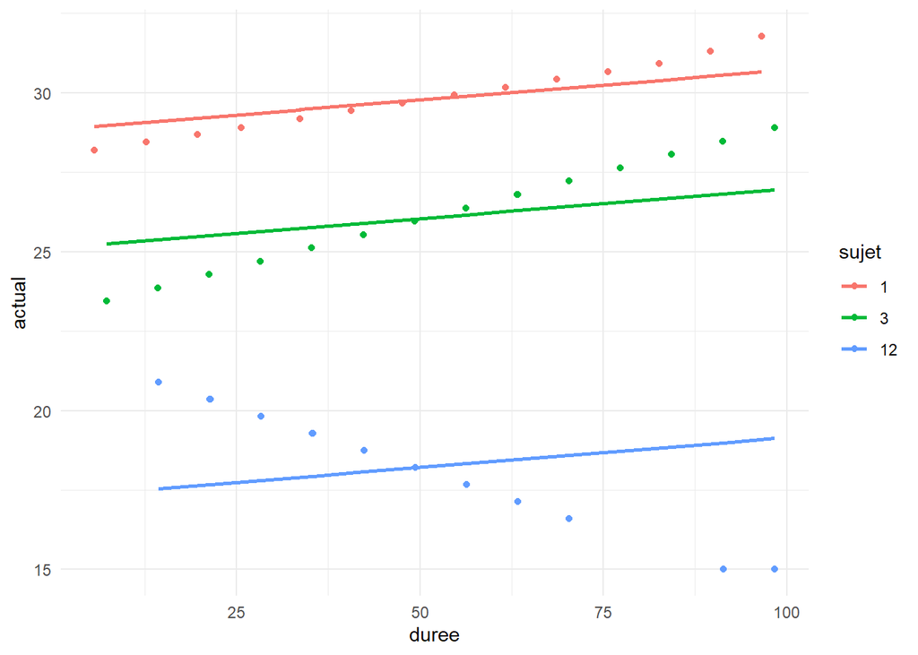

Cela est problématique car il nous est impossible de modéliser correctement les scores. Notre conclusion est qu’au vu du jeu de données **BRUT** le modèle linéaire n’est pas un modèle adapté.

#### **Modele score ~ (sujet + duree)^2**

Dans cette partie nous testons une autre approche en rajoutant des variables d’interactions entre les termes. Nous testons dans un premier temps une simple relation de degrès 2 entre **sujet** et **durée** :

```r
model_lm_4 <- lm(score ~ (sujet + duree)^2, data =apprentissage)
my.summary.lm(summary(model_lm_4),my.rows = c(2:4, 42:48))
```

```
##
## Call:
## lm(formula = score ~ (sujet + duree)^2, data = apprentissage)
##
## Residuals:
##      Min       1Q   Median       3Q      Max
## -0.73407 -0.00081  0.00000  0.00112  0.85278
##
## Coefficients:
##                Estimate Std. Error t value Pr(>|t|)
## sujet2       -1.695e+01  2.857e-02 -593.45   <2e-16 ***
## sujet3       -4.954e+00  2.910e-02 -170.21   <2e-16 ***
## sujet4       -1.785e+01  2.994e-02 -596.32   <2e-16 ***
## sujet42      -7.947e+00  2.620e-02 -303.32   <2e-16 ***
## duree         3.672e-02  3.594e-04  102.19   <2e-16 ***
## sujet2:duree -1.652e-02  5.092e-04  -32.45   <2e-16 ***
## sujet3:duree  2.328e-02  5.086e-04   45.76   <2e-16 ***
## sujet4:duree  3.666e-02  5.131e-04   71.44   <2e-16 ***
## sujet5:duree -3.672e-02  5.227e-04  -70.26   <2e-16 ***
## sujet6:duree -5.812e-02  5.137e-04 -113.14   <2e-16 ***
## ---
## Signif. codes:  0 '***' 0.001 '**' 0.01 '*' 0.05 '.' 0.1 ' ' 1
##
## Residual standard error: 0.08855 on 3020 degrees of freedom
## Multiple R-squared:  0.9999, Adjusted R-squared:  0.9999
## F-statistic: 3.087e+05 on 83 and 3020 DF,  p-value: < 2.2e-16
```

```
## RMSE train :  0.0873405
```

```
## RMSE validation :  1.172411
```

Nous pouvons voir des résultats largement amélioré comparé à nos précédents modèles. Il faut néanmoins faire attention à ce type de méthodes, car en rajoutant d’avantages de variables , le nombre de coefficients explose, engendrant généralement des problèmes d’overfitting. Par exemple en testant avec ces variables :

```r
model_lm_5 <- lm(score ~ (sujet + duree + FF + FF.Abs + AV + AV.dB + AV.APQ11 + BTC2 + EFS + CDNL)^2, data =apprentissage)
```

```
## RMSE train :  0.07681077
```

```
## RMSE validation :  1.160875
```

Nous obtenons quasiment les mêmes résultats avec un nombre de paramètres beaucoup plus élevé.

### **Tableau Résultats LM**

| Modèle | Méthode | RMSE_train | RMSE_validation | Nb_coefficients | AIC |
| --- | --- | --- | --- | --- | --- |
| lm_1 | - | 1.47884349 | 2.614845 | 59 | - |
| lm_2 | Durée + sujet | 1.49639956 | 2.635391 | 43 | - |
| lm_3 | stepwise | 1.48005043 | 2.619569 | 50 | - |
| lm_4 | ElasticNet | 1.48010436 | 2.615213 | 60 | - |
| lm_5 | (Durée + sujet)^2 | 0.08734050 | 1.172411 | 84 | - |
| lm_6 | (Durée + sujet + ...)^2 | 0.07681077 | 1.160875 | 456 | - |

## **3.2 Modèles GLM**

Dans cette partie, nous testons cette fois-ci des modèles GLM. Bien que les GLM classiques ne permettent généralement pas de résoudre le problème d’autocorrélation, nous voulons voir si nous pouvons obtenir un modèle avec de meilleurs performances. Pour cela, nous allons dans une première partie ajuster plusieurs lois adaptées à la distribution de la variable réponse. Puis dans une deuxième partie construire plusieurs modèles à partir de celles-ci.

### **3.2.1 Ajustement de la variable réponse score**

Dans cette étape, nous cherchons à approcher la loi de notre variable réponse via des lois continues positives.

#### **Loi Normale tronquée**

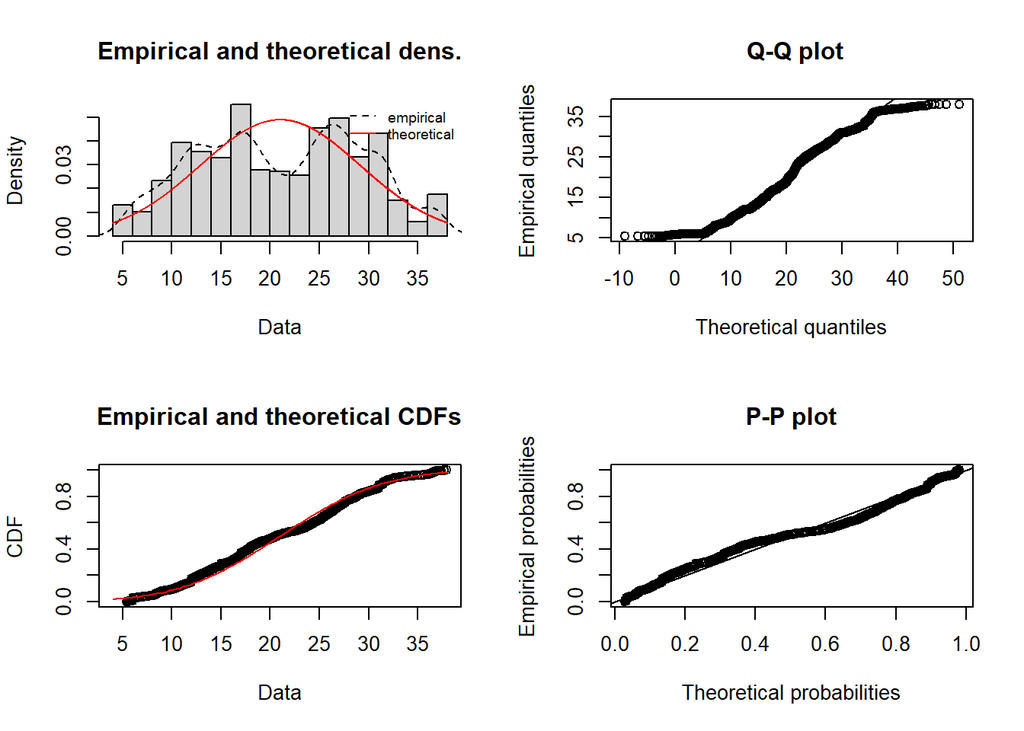

#### **Loi log normale**

```
## Fitting of the distribution ' lnorm ' by maximum likelihood
## Parameters :
##          estimate  Std. Error
## meanlog 2.9540742 0.006814657
## sdlog   0.4514164 0.004818584
## Loglikelihood:  -15698.72   AIC:  31401.43   BIC:  31414.21
## Correlation matrix:
##         meanlog sdlog
## meanlog       1     0
## sdlog         0     1
```

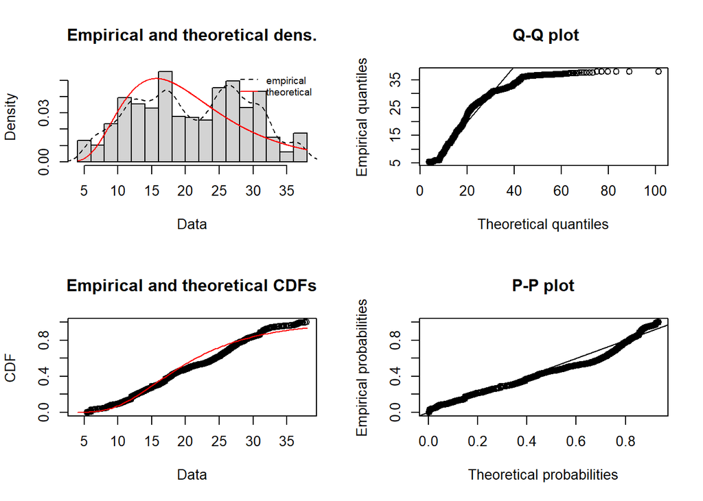

#### **Loi Gamma**

```
## Fitting of the distribution ' gamma ' by maximum likelihood
## Parameters :
##        estimate Std. Error
## shape 5.6722347         NA
## rate  0.2700402         NA
## Loglikelihood:  -15509.63   AIC:  31023.26   BIC:  31036.03
## Correlation matrix:
## [1] NA
```

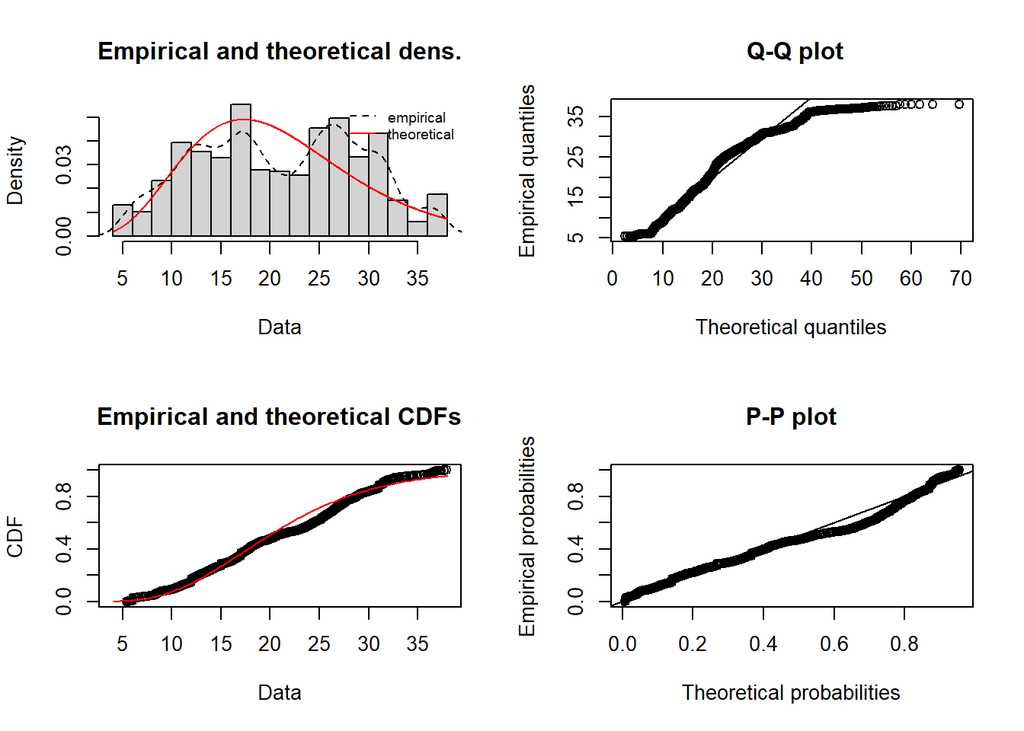

#### **Comparaison et conclusion**

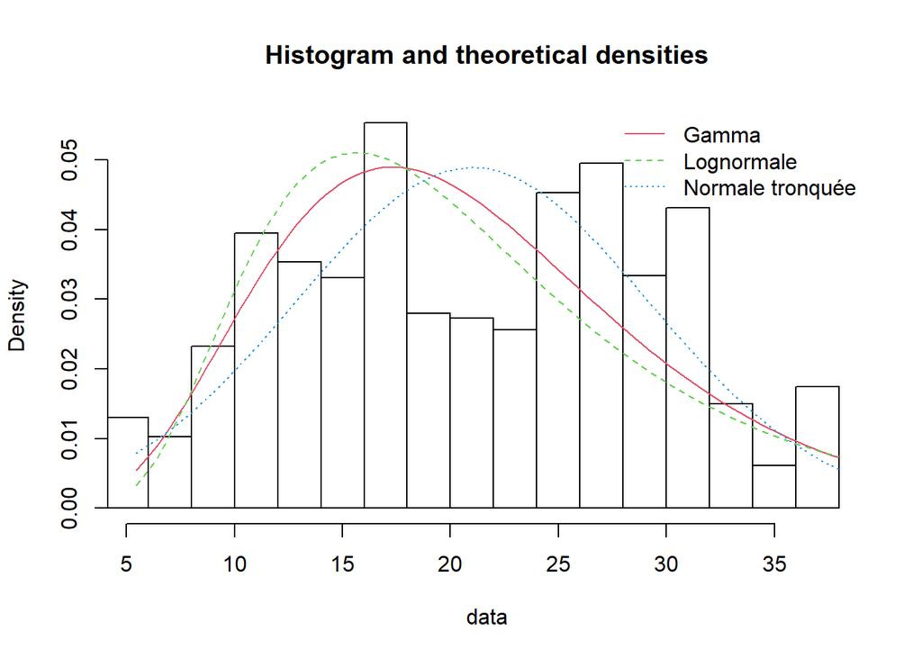

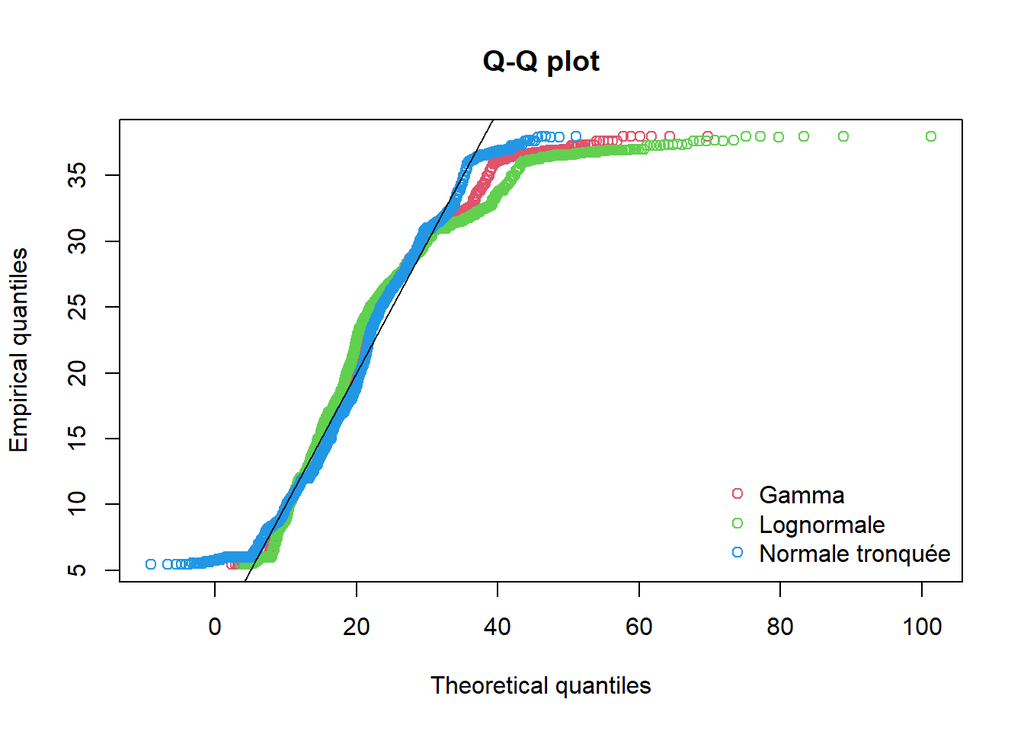

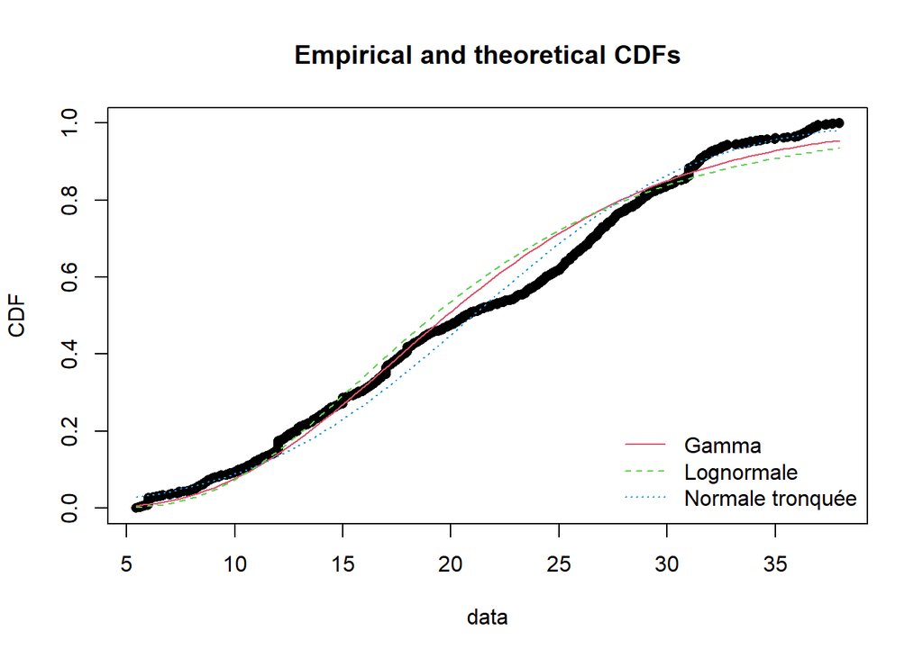

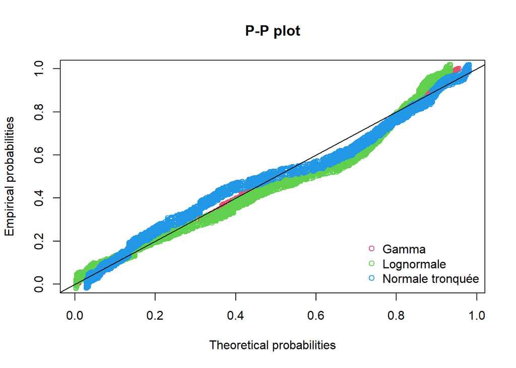

```
## Goodness-of-fit statistics
##                                    Gamma Lognormale Normale tronquée
## Kolmogorov-Smirnov statistic  0.09982486  0.1138995        0.0715631
## Cramer-von Mises statistic    8.29567713 11.7878876        6.5611089
## Anderson-Darling statistic   50.50465405 74.9420825       37.0483039
##
## Goodness-of-fit criteria
##                                   Gamma Lognormale Normale tronquée
## Akaike's Information Criterion 31023.26   31401.43         30882.16
## Bayesian Information Criterion 31036.03   31414.21         30894.94
```

En observant les résultats d’AIC, BIC et des différents tests statistiques sur la qualité d’ajustement, on conclue que le meilleur fit se fait avec la loi normale tronquée. Et en observant le plot de densités, il semble que la densité de la loi de la variable réponse se trouve entre la loi Gamma et la loi normale tronquée. Nous décidons alors de conserver les lois Gamma et normale tronquée pour nos modèles pour la construction de nos modèles.

Par la suite nous allons faire une selection de variables via plusieurs méthodes pour ces 2 lois, puis nous garderons le meilleur modèle parmi ceux construits.

### **3.2.2 Modèles via la loi Gamma**

Tout comme pour les modèles linéaire gaussien, nous modélisons les modèles avec toutes les variables puis avec (score + duree)^2

#### **Selection des variables manuellement via matrice de corrélation**

Pour rappel, nous avons observé que les variables au sein des blocs *FF* et *AA* sont fortement corrélees. Nous selectionnant alors pour ces 2 blocs la varibale la plus corrélée au score, à savoir respectivement *FF* et *AV.APQ11*, et retirons les autres. Puis nous modélisons le GLM et retirons manuellement les variables ayant des coefficients non significatifs. Affichons ces derniers à l’aide d’une fonction custom affichant par ordre croissant l’importance des coefficients :

```r
model_cor <- glm(formula= score ~ sujet + duree + FF + AV.APQ11 + BTC1 + BTC2 + CDNL + VFNL + EFS  ,data=apprentissage, family=Gamma(link="log"))
custom_summary_glm(model_cor)
```

```
##
## Call:
## glm(formula = score ~ sujet + duree + FF + AV.APQ11 + BTC1 +
##     BTC2 + CDNL + VFNL + EFS, family = Gamma(link = "log"), data = apprentissage)
##
##              coef         Pr(>|t|)     signif
## sujet30      0.0061       0.70675
## AV.APQ11     -0.0768      0.59313
## VFNL         -0.0196      0.58561
## BTC1         0.0401       0.57967
## CDNL         -0.0263      0.3076
## FF           0.883        0.13003
## sujet37      -0.0282      0.053842     .
## BTC2         0.00291      0.0035153    **
## sujet39      -0.0462      0.00062976   ***
## sujet31      0.0645       0.000408     ***
##
## (Dispersion parameter taken to be 0.007113604 )
##
## Null deviance :  564.1989  on 3103 degrees of freedom
## Resid deviance :  23.4137  on 3054 degrees of freedom
## AIC : 11981.88
## Number of Fisher scoring iterations : 5
```

Nous variables suivantes comme non significatives (p-value >0.05)et reconstruisons un modèle sans les inclure :

```
## [1] "FF"       "AV.APQ11" "BTC1"     "CDNL"     "VFNL"
```

En utilisant ces variables de départ, notre modèle nous ressort ceraines variables comme non significatives (p-value >0.05). Nous les retirons par la suite. Nous réitérons ce procédé avec les nouvelles variables et obtenons le RMSE :

```
## RMSE train :  1.488994
```

```
## RMSE validation :  2.633998
```

#### **Selection de variables via méthodes pas à pas**

Nous utilisons comme algorithmes de selection pas à pas les algorithmes backward, forward et both.  
Dans les méthodes qui suivent nous repartons de sujet, durée et toutes les variables cliniques. Nous obtenons au final les résultats suivants pour chaque méthodes :

*Backward*

```
##
## Call:
## glm(formula = score ~ sujet + duree + FF.DDP + AV + AV.APQ5 +
##     BTC2 + EFS, family = Gamma(link = "log"), data = apprentissage)
```

```
## AIC :  11974.62
```

*Forward*

```
##
## Call:
## glm(formula = score ~ (sujet + duree + FF + FF.Abs + FF.RAP +
##     FF.PPQ5 + FF.DDP + AV + AV.dB + AV.APQ3 + AV.APQ5 + AV.APQ11 +
##     AV.DDA + BTC1 + BTC2 + CDNL + EFS + VFNL + PC1) - PC1, family = Gamma(link = "log"),
##     data = apprentissage)
```

```
## AIC :  11989.32
```

*Both*

```
##
## Call:
## glm(formula = score ~ sujet + duree + FF.DDP + AV + AV.APQ5 +
##     BTC2 + EFS, family = Gamma(link = "log"), data = apprentissage)
```

```
## AIC :  11974.62
```

On obtient les mêmes variables selectionnées entre la méthode stepwise et backward. En se basant sur la métrique AIC nous conservons ces variables. Regardons le RMSE :

```
## RMSE train :  1.484247
```

```
## RMSE validation :  2.626595
```

#### **Selection via matrice de corrélation + stepwise**

Dans cette méthode, nous partons des variables selectionnées via la matrice de corrélation, puis effectuons un stepwise directement dessus

```
##
## Call:
## glm(formula = score ~ sujet + duree + FF + BTC2 + EFS, family = Gamma(link = "log"),
##     data = apprentissage)
##
##              coef         Pr(>|t|)     signif
## sujet30      0.00508      0.73982
## sujet37      -0.027       0.055212     .
## FF           0.987        0.0082445    **
## sujet31      0.061        0.0006684    ***
## sujet39      -0.0462      0.00050942   ***
## EFS          -0.202       1.4818e-05   ***
## sujet21      -0.071       1.9474e-06   ***
## sujet26      -0.0756      1.6435e-06   ***
## sujet6       -0.0677      1.096e-06    ***
## BTC2         0.00361      7.7617e-07   ***
##
## (Dispersion parameter taken to be 0.007108165 )
##
## Null deviance :  564.1989  on 3103 degrees of freedom
## Resid deviance :  23.42908  on 3058 degrees of freedom
## AIC : 11975.92
## Number of Fisher scoring iterations : 5
```

```
## RMSE train :  1.486981
```

```
## RMSE validation :  2.62952
```

#### **Selection via variables ACP**

```r
# Ajuster un modèle GLM avec les variables sujet, durée et PCA1
model_acp <- glm(score ~ sujet + duree + PC1,  data = apprentissage, family = Gamma(link = "log"))
#custom_summary_glm(model_acp)
```

```
## RMSE train :  1.487332
```

```
## RMSE validation :  2.659665
```

### **3.2.3 Modèle avec la loi normale tronquée :**

Tout comme précédemment, nous utlisons des méthodes de selections de variables. Cependant nous nous limiterons à la méthode de selection manuelle avec la corrélation et l’ACP. Nous testerons aussi un modèle GLM loi normale tronquée avec les variables selectionnées par le stepwise que l’on a obtenu avec le GLM loi Gamma.

## **3.3 Bilan modèles**

Comparons à présent tous nos modèles construits jusqu’à présent, nous ordonnant les modèle selon la métrique de RMSE validation :

| Modèle | Méthode | RMSE_train | RMSE_validation | Nb_coefficients | AIC |
| --- | --- | --- | --- | --- | --- |
| lm_6 | (Durée + sujet + ...)^2 | 0.07681077 | 1.160875 | 456 | - |
| lm_5 | (Durée + sujet)^2 | 0.08734050 | 1.172411 | 84 | - |
| gamma_6 | (Duree + sujet)^2 | 0.13227008 | 1.463488 | 84 | -1523.2200855671 |
| tronquee_normale_2 | Stepwise | 1.48570720 | 2.611884 | 48 | 11362.4490199075 |
| lm_1 | - | 1.47884349 | 2.614845 | 59 | - |
| lm_4 | ElasticNet | 1.48010436 | 2.615213 | 60 | - |
| tronquee_normale_1 | Corr manuelle | 1.48637255 | 2.618106 | 47 | 11363.2288859713 |
| lm_3 | stepwise | 1.48005043 | 2.619569 | 50 | - |
| gamma_1 | - | 1.48217857 | 2.625582 | 59 | 11989.3205062651 |
| gamma_3 | Stepwise | 1.48424682 | 2.626595 | 48 | 11974.618223993 |
| gamma_4 | Stepwise + corrélation | 1.48698061 | 2.629520 | 46 | 11975.9220455224 |
| tronquee_normale_3 | Modèle avec ACP | 1.48942641 | 2.632449 | 45 | 11371.9693586118 |
| gamma_2 | Corrélation | 1.48899387 | 2.633998 | 45 | 11980.5390847184 |
| lm_2 | Durée + sujet | 1.49639956 | 2.635391 | 43 | - |
| gamma_5 | Modèle avec ACP | 1.48733186 | 2.659665 | 44 | 11994.8410346056 |

Notons également que le RMSE de validation est bien plus élevé que celui de l’apprentissage, cela peut s’expliquer de 2 manières.  
D’une part, nous savons que ces modèles ne parviennent pas à généraliser correctement notre variable réponse. Mais aussi et surtout, comme observée sur la partie analyse descriptive, nous observons un changement abrupt de la relation durée/score à partir d’un certain seuil de durée. Notre set de validation ne comportant que des observations dont la durée est supérieur au quantile 70% cela confirme la tendance graphique observée.

Concernant le choix la prédiction et le modèle finale, nous décidons de retenir le modèle linéaire gaussien avec interaction **durée** et **sujet** (*lm_5*), d’une part, car le RMSE est meilleur en comparaison aux modèles sans interactions mais aussi par sa simplicité de fonctionnement, comparé aux modèles avec autres lois.  
Nous mettons aussi de côté le modèle avec plus d’interactions car sa performance est à peine meilleure, pour un nombre de paramètres bien plus éleve.

Egalement nous faisons le choix délibéré de nous entrainer sur l’ensemble du jeu de données (et donc pas seulement sur le train, validation ou meme le test…) malgré le changement de tendance sur les durées finales. Nous justifions ce choix car nous ne savons pas par la suite si cette tendance se poursuivra pour le jeu de test. De plus s’entrainer sur seulement une portion faible du dataset peut être risqué, encore plus si la tendance change de nouveau après le train.

Enfin nous avons gardé jusqu’à présent un set de test. Nous n’utiliserons ce dernier seulement pour comparer les modèles notre modèle final, avec des modèles complémentaires, et faire une dernière estimation de notre possible erreur attendu.

# **4.Modèle final**

Comme dit précédemment notre modèle final, sera le modèle linéaire classique avec interaction :

```r
mod_Final <- lm(score ~ (sujet + duree)^2, data =train_final)
my.summary.lm(summary(mod_Final),my.rows = c(2:4, 41:50))
```

```
##
## Call:
## lm(formula = score ~ (sujet + duree)^2, data = train_final)
##
## Residuals:
##     Min      1Q  Median      3Q     Max
## -5.1008 -0.3009  0.0001  0.3169  3.3945
##
## Coefficients:
##                Estimate Std. Error t value Pr(>|t|)
## sujet2       -1.699e+01  2.041e-01 -83.266  < 2e-16 ***
## sujet3       -4.002e+00  2.060e-01 -19.426  < 2e-16 ***
## sujet4       -1.692e+01  2.110e-01 -80.210  < 2e-16 ***
## sujet41       2.070e+00  1.969e-01  10.510  < 2e-16 ***
## sujet42      -6.559e+00  1.900e-01 -34.511  < 2e-16 ***
## duree         4.529e-02  1.836e-03  24.665  < 2e-16 ***
## sujet2:duree -1.583e-02  2.609e-03  -6.066 1.43e-09 ***
## sujet3:duree  6.277e-04  2.595e-03   0.242    0.809
## sujet4:duree  1.474e-02  2.620e-03   5.626 1.96e-08 ***
## sujet5:duree -3.562e-02  2.592e-03 -13.739  < 2e-16 ***
## sujet6:duree -5.040e-02  2.599e-03 -19.396  < 2e-16 ***
## sujet7:duree -3.674e-02  2.586e-03 -14.210  < 2e-16 ***
## sujet8:duree -2.499e-02  2.618e-03  -9.542  < 2e-16 ***
## ---
## Signif. codes:  0 '***' 0.001 '**' 0.01 '*' 0.05 '.' 0.1 ' ' 1
##
## Residual standard error: 0.7527 on 4304 degrees of freedom
## Multiple R-squared:  0.9917, Adjusted R-squared:  0.9915
## F-statistic:  6165 on 83 and 4304 DF,  p-value: < 2.2e-16
```

## **4.1 Analyse des outliers**

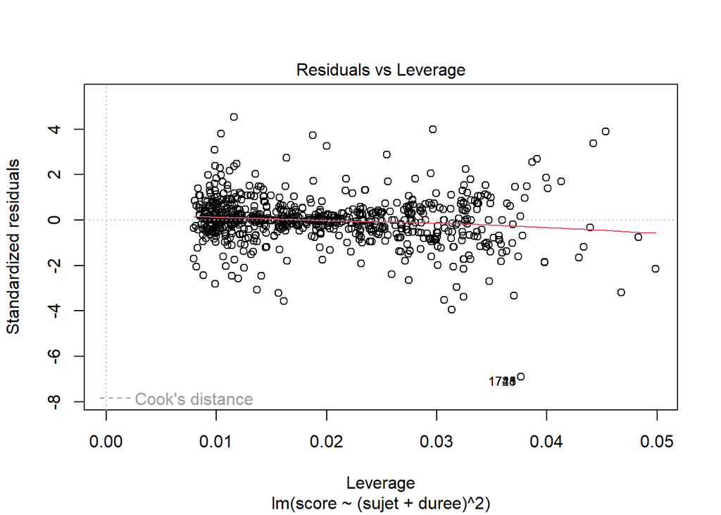

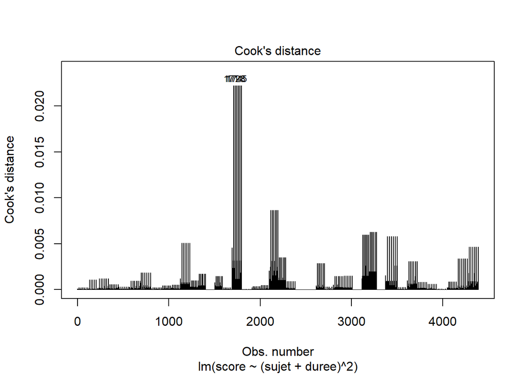

En analysant les différentes distance de Cook, nous observons que bien que certains points semblent se détacher des autres, aucun n’est significatif sur l’estimation des coefficients (distance < 1).